# 3 Limpieza de datos

Refactoring y depuración de las bases de datos

Autor/a

Mario Camacho

Fecha de publicación

26 abril 2026

## 3.1 Pediatría

Estructura interna de la base de datos:

```
tibble [67,961 × 25] (S3: tbl_df/tbl/data.frame)
 $ CIP_ANON                     : Factor w/ 67961 levels "1000100852","100035"..
 $ Fecha de nacimiento          : POSIXct[1:67961], format: "2018-01-01" ...
 $ sexo                         : Factor w/ 2 levels "Hombre","Mujer": 1 1 ...
 $ Peso al nac                  : num [1:67961] 3285 ...
 $ e. madre                     : num [1:67961] NA 27 ...
 $ Control                      : Factor w/ 2 levels "No","Sí": 2 2 ...
 $ e. maternal                  : Factor w/ 2 levels "No","Sí": 2 1 ...
 $ lugar_parto                  : Factor w/ 6 levels "Clínica Privada",..: 4 4..
 $ tipo_parto                   : Factor w/ 2 levels "Distócico","Eutócico": 1..
 $ Apgar 1MIN                   : num [1:67961] 9 10 ...
 $ Apgar 5MIN                   : num [1:67961] 10 10 ...
 $ edad gestacional             : num [1:67961] 374 39.4 ...
 $ Fecha del alta               : POSIXct[1:67961], format: "2018-01-02" ...
 $ tipo_lactancia               : Factor w/ 3 levels "Materna","Artificial",....
 $ d. lac materna               : num [1:67961] NA NA ...
 $ formulas especiales          : Factor w/ 2 levels "No","Sí": NA NA ...
 $ Test metabolopatías          : Factor w/ 2 levels "No","Sí": 2 2 ...
 $ Fecha Test                   : POSIXct[1:67961], format: "2018-01-03" ...
 $ Resultado test metabolopatías: Factor w/ 2 levels "Normal","Patológica": 1 ..
 $ mes_nacimiento               : Factor w/ 12 levels "1","2","3","4",..: 1 1 ..
 $ year_nacimiento              : Factor w/ 5 levels "2018","2019",..: 1 1 ...
 $ mes_alta                     : Factor w/ 12 levels "1","2","3","4",..: 1 1 ..
 $ year_alta                    : Factor w/ 66 levels "1900","2000",..: 16 16 ..
 $ mes_test                     : Factor w/ 12 levels "1","2","3","4",..: 1 1 ..
 $ year_test                    : Factor w/ 55 levels "1900","1997",..: 15 15 ..
```

**Eliminamos valor con e. madre < 14.**

Mantenemos los valores sin informar (NA) y los mayores e iguales a 14.

```
Antes: 67961. Después: 67945. Eliminados: 16
```

**Eliminamos valores extremos de e. madre (>= 80).**

```r
filtro <- is.na(pediatria$`e. madre`) | pediatria$`e. madre` < 80
```

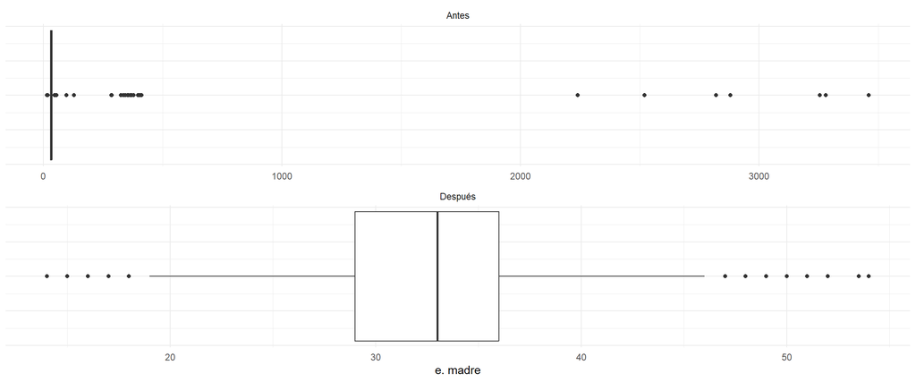

```
Antes: 67945. Después: 67921. Eliminados: 24
```

**Eliminamos valores extremos de días de lactancia materna (>= 200).**

```r
filtro <- is.na(pediatria$`d. lac materna`) | pediatria$`d. lac materna` < 200
```

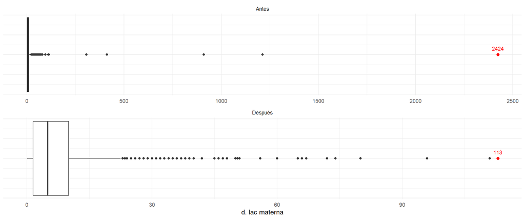

```
Antes: 67921. Después: 67916. Eliminados: 5
```

**Filtramos las fechas de test anteriores al nacimiento**

No aplica.  
- Finalmente no mostramos interés en el test de metabolopatías y no es necesario aplicar filtros al respecto.

```r
# Hay fechas test de 1900 en la base de datos original (2) + otra de 1997 (1).
# Fecha test tiene 27701 sin informar + 7 casos con fechas en formatos erróneos que el sistema interpreta como Na (anteriores a 1900)
filtro <- pediatria$`Fecha Test` < pediatria$`Fecha de nacimiento`
```

**Filtramos las fechas de alta anteriores al nacimiento**

```r
filtro <- pediatria$`Fecha del alta` < pediatria$`Fecha de nacimiento`
```

```
filtro
FALSE  TRUE  <NA>
48469   608 18839
```

```
Antes: 67916. Después: 67308. Eliminados: 608
```

**Filtramos los años de alta y test fuera del rango 2018-2023**

El estudio incluye nacimientos hasta 2022: damos un año más de margen (todos los datos incluidos son bebés menores de un año)

```r
anyos <- as.character(2018:2023)
filtro1 <- is.na(pediatria$year_alta) | pediatria$year_alta%in%anyos
filtro2 <- is.na(pediatria$year_test) | pediatria$year_test%in%anyos
```

Distribución de los años de alta:

```
 2018  2019  2020  2021  2022  2023  2024  2025  2028  2029  2033  2034  2041
 9512  9914  9271  9484 10083    97     1     1     1     3     1     1     2
 2052  2080  2090  2100  2102  2108  2109  2180  2190  2200  2201  2202  2208
    2     4     3    23     1     2     7     3     2    14     5     2     1
 2210  2220  2300  2301  2501  2502  2507  2901  2918  2919  2921  3018  3019
    1     1     1     1     1     2     1     1     1     1     1     1     2
 3020  3330  4201  5018  5133  5202  7018  7201  7202  8201  8202  9202  <NA>
    1     1     1     2     1     1     1     1     1     2     1     1 18839
  Sum
67308
```

Distribución de los años de test:

```
 1900  1997  2000  2001  2002  2008  2009  2010  2011  2012  2014  2015  2016
    2     1    20     4     6     1     1    18     2    12     1     3     6
 2017  2018  2019  2020  2021  2022  2023  2024  2026  2027  2028  2029  2052
   33  7693  7922  7780  7897  8244   109     1     1     1     1     1     1
 2080  2090  2100  2108  2109  2121  2122  2180  2190  2200  2201  2202  2210
    4     4     8     3     4     3     1     1     2     6     1     5     1
 2218  2220  2300  2501  2502  2840  2918  2921  3019  3202  5018  5202  6202
    1     2     1     2     1     1     1     2     1     2     1     1     2
 8202  9201  9202  <NA>   Sum
    2     1     1 27482 67308
```

```
Antes: 67308. Después: 67021. Eliminados: 287
```

Tabla de frecuencias

year_alta × mes_alta

| year | 1 | 2 | 3 | 4 | 5 | 6 | 7 | 8 | 9 | 10 | 11 | 12 | Na | Sum |
| --- | --- | --- | --- | --- | --- | --- | --- | --- | --- | --- | --- | --- | --- | --- |
| 2018 | 678 | 717 | 722 | 698 | 769 | 792 | 842 | 864 | 837 | 926 | 824 | 803 | 0 | 9472 |
| 2019 | 799 | 712 | 869 | 783 | 861 | 831 | 887 | 902 | 838 | 836 | 768 | 795 | 0 | 9881 |
| 2020 | 745 | 757 | 731 | 711 | 800 | 807 | 858 | 874 | 792 | 806 | 738 | 629 | 0 | 9248 |
| 2021 | 660 | 661 | 825 | 748 | 791 | 757 | 849 | 842 | 855 | 840 | 807 | 821 | 0 | 9456 |
| 2022 | 845 | 764 | 772 | 777 | 854 | 824 | 905 | 969 | 811 | 863 | 818 | 861 | 0 | 10063 |
| 2023 | 65 | 2 | 0 | 1 | 1 | 2 | 4 | 3 | 3 | 0 | 5 | 10 | 0 | 96 |
| NA. | 0 | 0 | 0 | 0 | 0 | 0 | 0 | 0 | 0 | 0 | 0 | 0 | 18805 | 18805 |
| Sum | 3792 | 3613 | 3919 | 3718 | 4076 | 4013 | 4345 | 4454 | 4136 | 4271 | 3960 | 3919 | 18805 | 67021 |

Tabla de frecuencias

| year | 1 | 2 | 3 | 4 | 5 | 6 | 7 | 8 | 9 | 10 | 11 | 12 | Na | Sum |
| --- | --- | --- | --- | --- | --- | --- | --- | --- | --- | --- | --- | --- | --- | --- |
| 2018 | 533 | 595 | 600 | 563 | 642 | 708 | 702 | 687 | 652 | 765 | 630 | 603 | 0 | 7680 |
| 2019 | 622 | 574 | 697 | 597 | 659 | 676 | 697 | 716 | 730 | 686 | 614 | 631 | 0 | 7899 |
| 2020 | 628 | 646 | 618 | 625 | 645 | 671 | 727 | 708 | 646 | 691 | 620 | 549 | 0 | 7774 |
| 2021 | 562 | 584 | 694 | 605 | 703 | 639 | 703 | 684 | 730 | 685 | 666 | 628 | 0 | 7883 |
| 2022 | 658 | 655 | 611 | 654 | 702 | 694 | 719 | 797 | 706 | 718 | 659 | 659 | 0 | 8232 |
| 2023 | 73 | 10 | 1 | 1 | 1 | 2 | 3 | 2 | 1 | 1 | 2 | 11 | 0 | 108 |
| NA. | 0 | 0 | 0 | 0 | 0 | 0 | 0 | 0 | 0 | 0 | 0 | 0 | 27445 | 27445 |
| Sum | 3076 | 3064 | 3221 | 3045 | 3352 | 3390 | 3551 | 3594 | 3465 | 3546 | 3191 | 3081 | 27445 | 67021 |

**Distribución del peso al nacer: controversia con las unidades de medida**

El peso al nacer está registrado tanto en gramos como en kilos.

Se intentó identificar los casos registrados en kilos y transformarlo a gramos. Se considera demasiado complicado y muchos casos no sabían resolverse. Además, la variable ‘edad gestacional’ tampoco está debidamente informada, por lo que no puede usarse para inferir el peso en gramos o kilos.

Distribución del peso al nacimiento:

```
   Min. 1st Qu.  Median    Mean 3rd Qu.    Max.     NAs
      0    2660    3135    2994    3470 2777777    5961
```

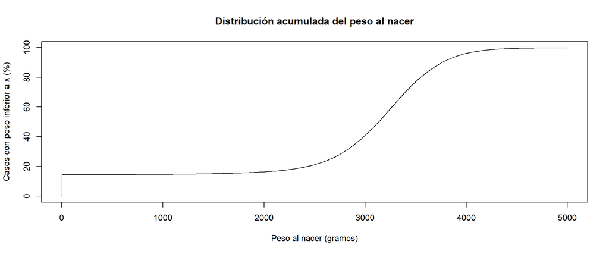

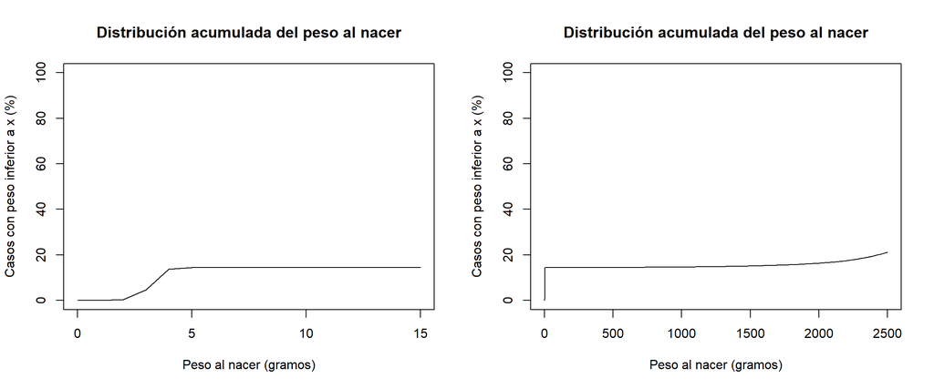

Distribución del peso al nacimiento por semana gestacional:

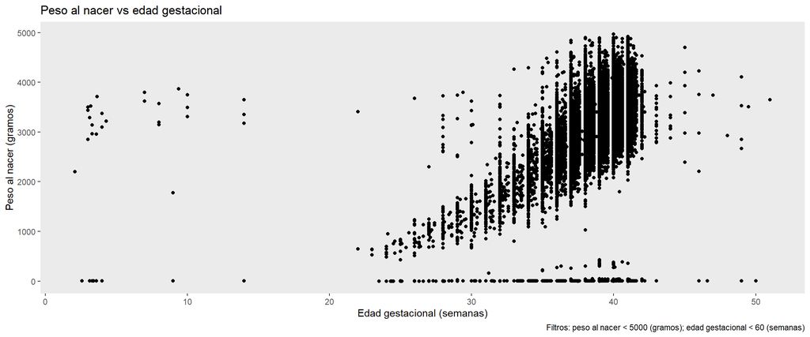

Los datos en la región verde se consideran debidamente informados. El resto de registros pueden corregirse bajo el supuesto de que los registros de arriba a la izquierda (la semana gestacional parece estar en meses, no en día) y abajo a la derecha (los datos parecen estar en kilos y no en gramos).

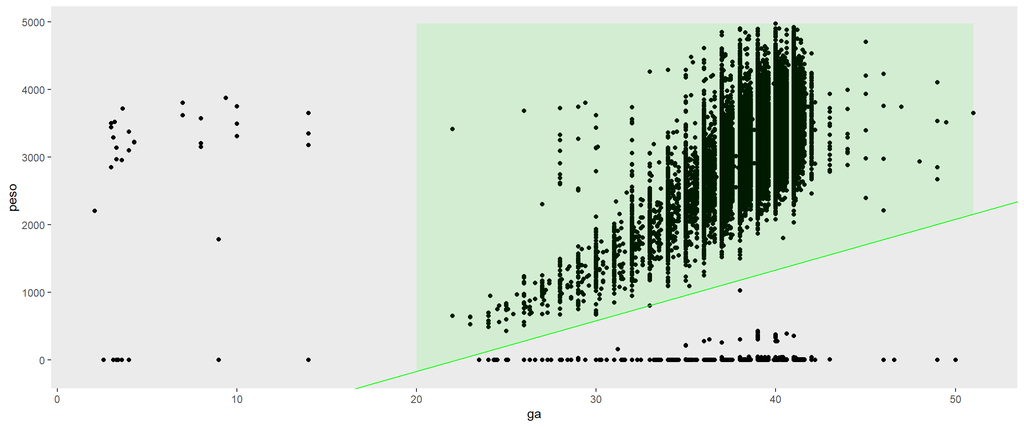

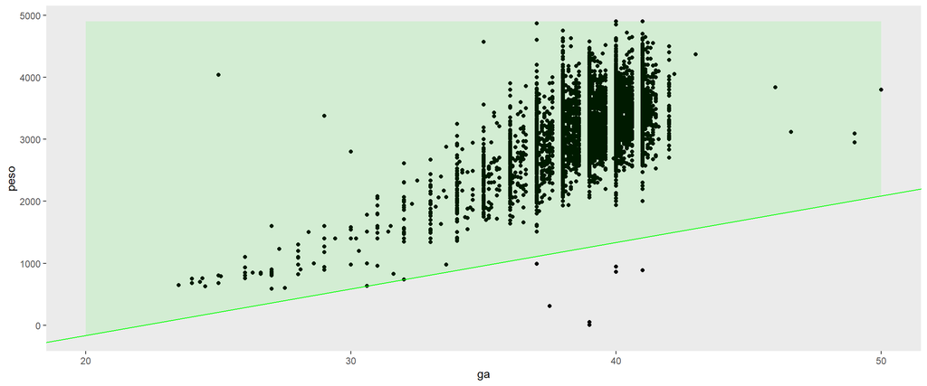

```
Casos corregidos: 8257
```

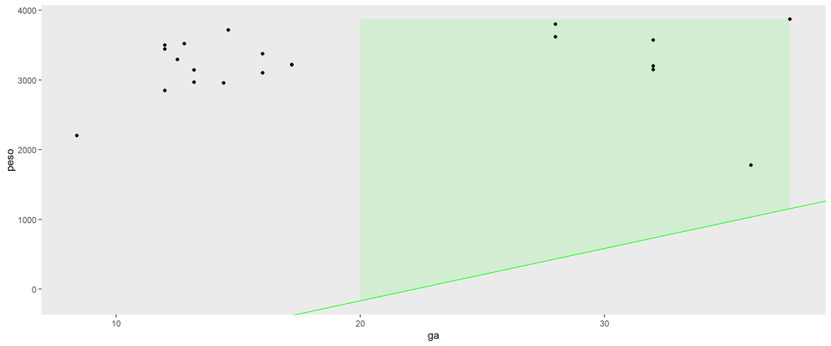

```
Casos corregidos: 22
```

Tras haber corregido las dos casuísticas de la edad gestacional y el peso al nacimiento, los datos en la región verde se consideran debidamente informados. Se eliminan el resto de valores.

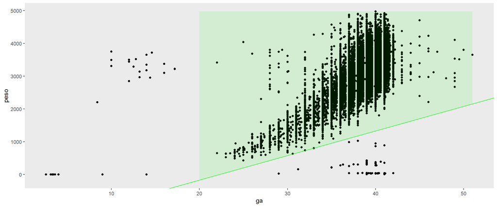

```
Antes: 67021. Después: 56899. Eliminados: 10122
```

**Filtramos los valores de Apgar (1MIN/5MIN) superiores a 10**

Valores de Apgar 1 minuto superiores a diez:

```
FALSE  TRUE  <NA>
47969    91  8839
```

Valores de Apgar 5 minutos superiores a diez:

```
FALSE  TRUE  <NA>
46060   102 10737
```

```
Antes: 56899. Después: 56706. Eliminados: 193
```

### 3.1.1 Warnings (dudas)

**Advertencia**

- ¿Diferencia entre e.maternal y e.madre?

```
               e. maternal
e.madre_missing    No    Sí  <NA>
          FALSE  8283 32149 13944
          TRUE    108   695  1527
          <NA>      0     0     0
```

- ¿Puede ser tipo de lactancia materna pero tener fórmulas especiales?

```
                No    Sí  <NA>
  Materna     2291   494 26113
  Artificial   966   428  7594
  Mixta        900   329  7939
  <NA>          17    15  9620
```

- Relación entre ‘Test metabolopatías’, ‘Resultado test metabolopatías’.

```
       Normal Patológica  <NA>
  No      118          1    67
  Sí    44708        293  9803
  <NA>    737          6   973
```

Si hay resultado del test de metabolopatías entonces el test se marca como “Sí”, y si el resultado es NA entonces el test se marca como “No”.

```
       Normal Patológica  <NA>
  No        0          0 10843
  Sí    45563        300     0
  <NA>      0          0     0
```

- Edad gestacional no podemos usarla: posiblemente haya valores en meses, otros en días y otros valores son demasiado extremos.

(edad gestacional original, antes de eliminar filtrar por los casos en verde)

```
     Min.   1st Qu.    Median      Mean   3rd Qu.      Max.       NAs
      2.6      38.0      39.0     256.9      40.0 4017082.0      9398
```

## 3.2 Pediatría y Protocolo salud

La base de datos de ‘protocolo salud’ contienen los cuestionarios de educación de lactancia: la escala de valoración LACTH y el test de Matthew.

```
# A tibble: 6 × 9
  CIP_ANON   Fechadenacimiento   sexo   testdeMatthew     EscaladevaloracionLA…¹
  <chr>      <dttm>              <chr>  <chr>             <chr>
1 1001248772 2022-10-07 00:00:00 MUJER  12 - LACTANCIA E… 10 - Sin dificultad/s…
2 1001303052 2022-07-30 00:00:00 MUJER  <NA>              <NA>
3 1001366112 2022-08-21 00:00:00 MUJER  12 - LACTANCIA E… 10 - Sin dificultad/s…
4 1001849002 2022-08-10 00:00:00 HOMBRE <NA>              <NA>
5 1002179042 2022-06-20 00:00:00 HOMBRE << No Procede >>  << No Procede >>
6 1002899452 2021-11-04 00:00:00 HOMBRE <NA>              <NA>
# ℹ abbreviated name: ¹EscaladevaloracionLACTH
# ℹ 4 more variables: motivoabandonodelactancia <chr>,
#   alimentacioncomplementaria <chr>, Tipodelecheartificial <chr>,
#   Calendariovacunacion <chr>
```

```
FALSE  TRUE
48636  8070
```

```
FALSE  TRUE
 4665  8070
```

Número de CIPs comunes en pediatría y protocolo salud:

```
[1] 8070
```

Distribución del año de nacimiento de los niños que tienen protocolo salud informado:

```
# A tibble: 5 × 4
  year_nacimiento Pediatría `Protocolo salud` `Unión Ped-Prot`
  <fct>               <int>             <int>            <int>
1 2018                12259               868               97
2 2019                11809               790               92
3 2020                10855               498               78
4 2021                10869               811              206
5 2022                10914              9768             7597
```

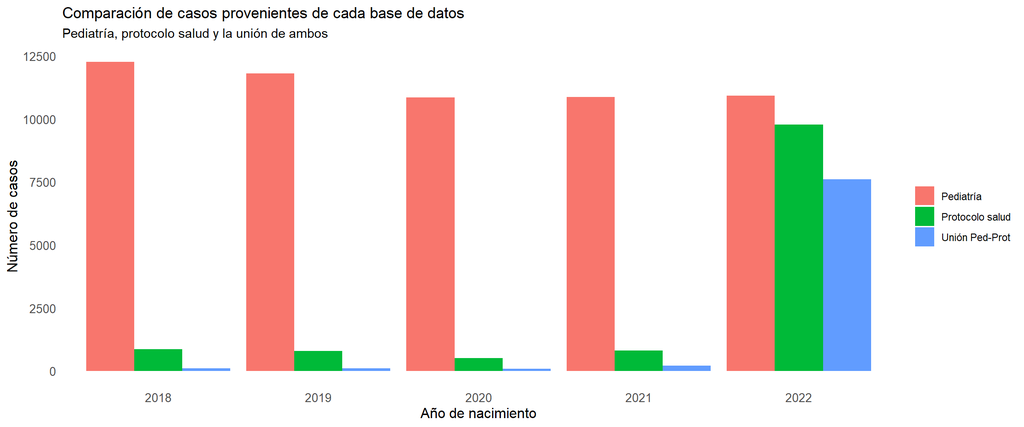

El registro de la escala de valoración LACTH y el test Matthew está implementado en la práctica clínica de forma voluntaria: el especialista decide si quiere recoger o no esta información. Desde 2022 -repasarlo con Esmeralda- creo que está relacionado con los programas de promoción de la leche materna para que se registre esta información.

**Escala de valoración LACTH**

Ejemplos de la escala de valoración de LACTH en la base de datos protocolo salud:

```
 [1] "10 - sin dificultad/situación óptima"
 [2] NA
 [3] "9 - sin dificultad/situación óptima"
 [4] "<< no procede >>"
 [5] "7 - dificultad moderada"
 [6] "8 - dificultad moderada"
 [7] "0 - importante dificultad"
 [8] "n"
 [9] "5 - dificultad moderada"
[10] "3 - importante dificultad"
```

Conservamos el resultado numérico de la escala de valoración LACTH únicamente cuando toma valores entre 0 y 10. En otro caso se clasifica como `sin determinar`, excepto cuando corresponde a `no procede`, que se mantiene como categoría específica.

```
         0         10          2          3          4          5          6
        19        873          5         10         22         30         59
         7          8          9 no procede       <NA>
        86        134        201       1063       5568
```

Ejemplos de la variable test de Matthew en la base de datos protocolo salud:

```
 [1] "12 - lactancia eficiente"         NA
 [3] "<< no procede >>"                 "8 - lact. medianamente eficiente"
 [5] "11 - lactancia eficiente"         "4 - lactancia deficiente"
 [7] "9 - lact. medianamente eficiente" "10 - lactancia eficiente"
 [9] "6 - lactancia deficiente"         "adecuada"
```

Conservamos el resultado numérico del test de Matthew únicamente cuando toma valores entre 0 y 10. En otro caso se clasifica como `sin determinar`, excepto cuando corresponde a `no procede`, que se mantiene como categoría específica.

```
         0          1         10          2          3          4          5
         8          3        114          5          4          7         14
         6          7          8          9 no procede       <NA>
        23         26         55         67        660       7084
```

Creamos las variables categóricas con los niveles asociados a la escala de valoración LACTH y el test de Matthew. Los registros no informados se clasifican como `sin determinar`, excepto cuando corresponde a `no procede`, que se mantiene como categoría específica.

```
            dificultad moderada           importante dificultad
                            367                              37
                     no procede                  sin determinar
                           1200                            9971
sin dificultad/situación óptima                            <NA>
                           1160                               0
```

```
            lactancia deficiente              lactancia eficiente
                              71                             3098
lactancia medianamente eficiente                       no procede
                             164                              754
                  sin determinar                             <NA>
                            8648                                0
```

## 3.3 Hospitalización

**Advertencia**

Tras depurar la base de datos de `Pediatria`, existen CIP_ANON en `Hospitalización` que no encontramos en `Pediatría`. También existían casos así antes de la depuración.

Ejemplo:

```r
# El CIP_ANON 1011124712 se elimina a no constar con GA
pediatria_bck |> filter(CIP_ANON=='1011124712')
## # A tibble: 1 × 19
##   CIP_ANON   `Fecha de nacimiento` sexo   `Peso al nac` `e. madre` Control
##   <chr>      <dttm>                <chr>          <dbl>      <dbl> <chr>
## 1 1011124712 2022-07-27 00:00:00   HOMBRE          2420         29 SI
## # ℹ 13 more variables: `e. maternal` <chr>, `lugar del parto` <chr>,
## #   `tipo de parto` <chr>, `Apgar 1MIN` <dbl>, `Apgar 5MIN` <dbl>,
## #   `edad gestacional` <dbl>, `fecha del alta` <dttm>,
## #   `tipo de lactancia` <chr>, `d. lac materna` <dbl>,
## #   `formulas especiales` <chr>, `Test metabolopatías` <chr>,
## #   `Fecha Test` <dttm>, `Resultado test metabolopatías` <chr>
pediatria |> filter(CIP_ANON=='1011124712')
## # A tibble: 0 × 25
## # ℹ 25 variables: CIP_ANON <fct>, Fecha de nacimiento <dttm>, sexo <fct>,
## #   Peso al nac <dbl>, e. madre <dbl>, Control <fct>, e. maternal <fct>,
## #   lugar_parto <fct>, tipo_parto <fct>, Apgar 1MIN <dbl>, Apgar 5MIN <dbl>,
## #   edad gestacional <dbl>, Fecha del alta <dttm>, tipo_lactancia <fct>,
## #   d. lac materna <dbl>, formulas especiales <fct>, Test metabolopatías <chr>,
## #   Fecha Test <dttm>, Resultado test metabolopatías <fct>,
## #   mes_nacimiento <fct>, year_nacimiento <fct>, mes_alta <fct>, …
hospitalizacion |> filter(CIP_ANON=='1011124712')
## # A tibble: 1 × 50
##   CENTRO CIP_ANON   FEC_NAC             SEXO  Q     ZBS    FEC_ING
##   <chr>  <chr>      <dttm>              <chr> <chr> <chr>  <dttm>
## 1 020019 1011124712 2022-07-27 00:00:00 1     16    110505 2022-11-23 01:46:00
## # ℹ 43 more variables: D1 <chr>, D2 <chr>, D3 <chr>, D4 <chr>, D5 <chr>,
## #   D6 <chr>, D7 <chr>, D8 <chr>, D9 <chr>, D10 <chr>, D11 <chr>, D12 <chr>,
## #   D13 <chr>, D14 <lgl>, D15 <lgl>, D16 <lgl>, D17 <lgl>, D18 <lgl>,
## #   D19 <lgl>, D20 <lgl>, UCI <chr>, DIAS_UCI <dbl>, FEC_FIN <dttm>,
## #   TIPALT <chr>, HOSPTRAS <chr>, GRD <chr>, DESCRIPCION <chr>, VERSION <chr>,
## #   SEVERIDAD <chr>, EDAD <dbl>, ENF_INF_INT <dbl>, OTRAS_BACT <dbl>,
## #   EXANT <dbl>, OTRAS_INF <dbl>, COVID <dbl>, INF_AGU_TRS <dbl>, …

table(hospitalizacion$CIP_ANON%in%pediatria$CIP_ANON)
##
## FALSE  TRUE
##  2434  2557
table(hospitalizacion$CIP_ANON%in%pediatria_bck$CIP_ANON)
##
## FALSE  TRUE
##  1940  3051
```

**Nota**

Inicialmente planteé eliminar de la base de `Hospitalización` todos los registros que no se encontraban en la base de datos de `Pediatría`, ya que esto me había generado problemas en pasos posteriores del proyecto y me obligó a repetir validaciones de bases de datos.

Finalmente no se realicé. Pero al analizar los datos de `Hospitalización` hay que tener en cuenta que pueden existir registros sin información basal disponible (tipo de lactancia, test de Matthews, edad gestacional, etc).

Total filas:

```
[1] 4991
```

Combinaciones únicas (CIP_ANON, FEC_NAC):

```
4449 filas, 2 columnas
```

Pacientes únicos:

```
[1] 4449
```

¿Cada CIP_ANON tiene una única FEC_NAC?

```
[1] "Sí"
```

```
Tenemos 532 registros en la base de datos 'hospitalización' sin código de ZBS.
```

Casos con ZBS no informado:

```
FALSE  TRUE
 4459   532
```

Aparentemente, un CENTRO no está asociado únicamente a un ZBS en la base de datos.

```
# A tibble: 6 × 3
  CENTRO year_ingreso `Nº de ZBS asociados`
  <chr>         <dbl>                 <int>
1 020019         2017                     5
2 020019         2018                    33
3 020019         2019                    33
4 020019         2020                    27
5 020019         2021                    25
6 020019         2022                    32
```

```
# A tibble: 6 × 4
  CENTRO CIP_ANON   year_ingreso ZBS
  <chr>  <chr>             <dbl> <chr>
1 020019 5665583571         2017 110114
2 020019 944587651          2017 110123
3 020019 4445782031         2017 110128
4 020019 4650589171         2017 110128
5 020019 1272977181         2017 110130
6 020019 6495410181         2017 110130
```

Existen casos en los que un mismo CIP presenta más de una hospitalización y algunos registros tienen el campo ZBS informado mientras que otros registros no. Para imputar los registros de ZBS sin informar, a cada CIP le asigno las visitas de cada añoal mismo ZBS siempre.

```r
hospitalizacion |> mutate(year_ingreso = year(FEC_ING)) |> filter(CIP_ANON==2967241511) |> select(CENTRO, CIP_ANON, year_ingreso, ZBS, D1:D3)
## # A tibble: 6 × 7
##   CENTRO CIP_ANON   year_ingreso ZBS    D1    D2     D3
##   <chr>  <chr>             <dbl> <chr>  <chr> <chr>  <chr>
## 1 130087 2967241511         2018 110222 J22   R06.02 G12.0
## 2 130087 2967241511         2018 110222 J22   J96.20 G12.0
## 3 130087 2967241511         2018 110222 J22   R06.02 G12.0
## 4 130087 2967241511         2018 110222 J22   G12.0  Z82.79
## 5 130127 2967241511         2018 <NA>   J21.0 J96.10 G12.0
## 6 130127 2967241511         2018 <NA>   J06.9 J96.10 G12.0
```

```
# A tibble: 6 × 7
  CENTRO CIP_ANON   year_ingreso ZBS    D1    D2     D3
  <chr>  <chr>             <dbl> <chr>  <chr> <chr>  <chr>
1 130087 2967241511         2018 110222 J22   R06.02 G12.0
2 130087 2967241511         2018 110222 J22   J96.20 G12.0
3 130087 2967241511         2018 110222 J22   R06.02 G12.0
4 130087 2967241511         2018 110222 J22   G12.0  Z82.79
5 130127 2967241511         2018 110222 J21.0 J96.10 G12.0
6 130127 2967241511         2018 110222 J06.9 J96.10 G12.0
```

```
# A tibble: 6 × 3
  CENTRO year_ingreso `Nº de ZBS asociados`
  <chr>         <dbl>                 <int>
1 020019         2017                     5
2 020019         2018                    33
3 020019         2019                    33
4 020019         2020                    27
5 020019         2021                    25
6 020019         2022                    32
```

No se consigue reducir mucho el número de casos con ZBS no informado:

```
FALSE  TRUE
 4503   488
```

## 3.4 Patologías

Cabecera de diagnósticos en la base de datos `hospitalización`:

```
# A tibble: 6 × 12
  D1     D2    D3    D4    D5    D6    D7    D8    D9    D10   D11   D12
  <chr>  <chr> <chr> <chr> <chr> <chr> <chr> <chr> <chr> <chr> <chr> <chr>
1 A08.39 E86.0 <NA>  <NA>  <NA>  <NA>  <NA>  <NA>  <NA>  <NA>  <NA>  <NA>
2 J06.9  <NA>  <NA>  <NA>  <NA>  <NA>  <NA>  <NA>  <NA>  <NA>  <NA>  <NA>
3 J21.9  J18.9 K52.9 Q18.1 <NA>  <NA>  <NA>  <NA>  <NA>  <NA>  <NA>  <NA>
4 K52.9  E86.0 B15.9 <NA>  <NA>  <NA>  <NA>  <NA>  <NA>  <NA>  <NA>  <NA>
5 B34.9  D70.9 <NA>  <NA>  <NA>  <NA>  <NA>  <NA>  <NA>  <NA>  <NA>  <NA>
6 A04.5  <NA>  <NA>  <NA>  <NA>  <NA>  <NA>  <NA>  <NA>  <NA>  <NA>  <NA>
```

```
[1] 599
```

```
Códigos de diagnóstico en las columnas D1-D12 sin descripción: 599
```

```
Top códigos faltantes (n): A04.5 (1), A04.6 (1), A04.8 (1), A04.9 (1), A08.0 (1)
```

## 3.5 Grupos Relacionados por el Diagnóstico (Portal Estadístico)

El descriptivo de algunos GDR ha cambiado a lo largo de los años.

| GRD CDM | GRD | Severidad | 2016 | 2017 | 2018 | 2019 | 2020 | 2021 | 2022 | 2023 | 2024 |
| --- | --- | --- | --- | --- | --- | --- | --- | --- | --- | --- | --- |
| 144-ENFERMEDADES MISCELANEAS, SIGNOS Y SÍNTOMAS DE APARATO RESPIRATORIO | 144 | 2 | NA | NA | NA | NA | NA | NA | 3291.16 | 3680.56 | 3738.68 |
| 144-OTROS DIAGNÓSTICOS MENORES, SIGNOS Y SÍNTOMAS DE APARATO RESPIRATORIO | 144 | 2 | 2668.67 | 2600.99 | 2668.23 | 2735.23 | 3076.6 | 2962.19 | NA | NA | NA |

Agrupo la información a nivel código de GRD e ignoro el descriptivo.

| GRD | Severidad | 2016 | 2017 | 2018 | 2019 | 2020 | 2021 | 2022 | 2023 | 2024 |
| --- | --- | --- | --- | --- | --- | --- | --- | --- | --- | --- |
| 144 | 2 | 2668.67 | 2600.99 | 2668.23 | 2735.23 | 3076.6 | 2962.19 | 3291.16 | 3680.56 | 3738.68 |

## 3.6 Prevalencias

Correcciones validadas con el fichero Excel original:  
- Columna `177-PREV. L ART12 M` pertenece al año 2017, se corrige como `17-PREV. L ART12 M`.  
- Columna `23-PREV. L. ARTIFIC 4 M` pertenece al año 2022, se corrige como `22-PREV. L. ARTIFIC 4 M`.

Otras correciones:  
- En el año 2015:  
- Solo tenemos seguimiento a los 4 y 6 meses.  
- Tenemos valores absolutos, debemos calcular a mano el porcentaje que representa cada tipo de lactancia sobre el total de casos con seguimiento.  
- No tenemos datos de lactancia artificial, solo exclusiva y mixta.  
- Debemos estimar el número de casos de lactancia artificial para poder calcular la distribución del tipo de lactancia.  
- A ojo, y mirando otros años, a los cuatro meses se hace un seguimiento de 4/9 de los seguimientos. Con este dato estimamos el número de casos de lactancia artificial y podemos calcula la distribución del tipo de lactancia.  
- A los seis meses suele ser algo superior, de unos 5/9.  
- Entonces lo que hago es: i) estimo el número de casos de seguimiento de la lactancia artificial como el punto medio entre el porcentaje de casos se seguimiento en lactancia artificial de 2014 sobre el total de naciemientos del 2014 y el porcentaje de casos de seguimiento que han sido lactancia artificial en 2016 sobre el total de nacimiento de 2016, ii) una vez tengo el númeor de casos estimados a los que se les ha hecho seguiiento en 2015 para la lactancia artificail, calculo el total de casos de seguimiento, iii) calculo la prevalencia para cada tipo de leche.

```r
prevalencias <- prevalencias |> rename(`17-PREV. L ART12 M`=`177-PREV. L ART12 M`, `22-PREV. L. ARTIFIC 4 M`=`23-PREV. L. ARTIFIC 4 M`)

### Opción 1
# prevalencias <- prevalencias |>
#   mutate(`15_4M_ART` = ceiling(`15_NAC` * 4/9),
#          `15_4M_ Nº` = `15_4M_EXC` + `15_4M_MIX` + `15_4M_ART`) |>
#   mutate(`15-PREV. LM EXCLU 4 M` = `15_4M_EXC` / `15_4M_ Nº`,
#          `15-PREV. LM MIXTA 4 M` = `15_4M_MIX` / `15_4M_ Nº`,
#          `15-PREV. L. ARTIFIC 4 M` = `15_4M_ART` / `15_4M_ Nº`) |>
#   mutate(`15_6M_ART` = ceiling(`15_NAC` * 5/9),
#          `15_6M_ Nº` = `15_6M_EXC` + `15_6M_MIX` + `15_6M_ART`) |>
#   mutate(`15-PREV. LM EXCLU 6 M` = `15_6M_EXC` / `15_6M_ Nº`,
#          `15-PREV. LM MIXTA 6 M` = `15_6M_MIX` / `15_6M_ Nº`,
#          `15-PREV. L. ARTIFIC 6 M` = `15_6M_ART` / `15_6M_ Nº`)

### Opción 2
# prev_art_15_4M <- rowMeans(prevalencias[, c('14-PREV. L. ARTIFIC 4 M','16-PREV. L. ARTIFIC 4 M')], na.rm = TRUE)
# prev_art_15_6M <- rowMeans(prevalencias[, c('14-PREV. L. ARTIFIC 6 M','16-PREV. L. ARTIFIC 6 M')], na.rm = TRUE)
#
# cbind('14-PREV. L. ARTIFIC 4 M'=prevalencias$'14-PREV. L. ARTIFIC 4 M',
#       '15-PREV. L. ARTIFIC 4 M'=prev_art_15_4M,
#       '16-PREV. L. ARTIFIC 4 M'=prevalencias$'16-PREV. L. ARTIFIC 4 M') |> head()
#
# (cbind('14-PREV. L. ARTIFIC 4 M'=prevalencias$'14-PREV. L. ARTIFIC 4 M',
#       '15-PREV. L. ARTIFIC 4 M'=prev_art_15_4M,
#       '16-PREV. L. ARTIFIC 4 M'=prevalencias$'16-PREV. L. ARTIFIC 4 M') |> colSums(na.rm = TRUE))/dim(prevalencias)[1]
#
# prevalencias <- prevalencias |>
#   mutate(`15-PREV. L. ARTIFIC 4 M` = prev_art_15_4M,
#          `15_4M_ART` = ceiling(`15_NAC` * prev_art_15_4M),
#          `15_4M_ Nº` = `15_4M_EXC` + `15_4M_MIX` + `15_4M_ART`,
#          `15-PREV. LM EXCLU 4 M` = `15_4M_EXC` / `15_4M_ Nº`,
#          `15-PREV. LM MIXTA 4 M` = `15_4M_MIX` / `15_4M_ Nº`) |>
#   mutate(`15-PREV. L. ARTIFIC 6 M` = prev_art_15_6M,
#          `15_6M_ART` = ceiling(`15_NAC` * prev_art_15_6M),
#          `15_6M_ Nº` = `15_6M_EXC` + `15_6M_MIX` + `15_6M_ART`,
#          `15-PREV. LM EXCLU 6 M` = `15_6M_EXC` / `15_6M_ Nº`,
#          `15-PREV. LM MIXTA 6 M` = `15_6M_MIX` / `15_6M_ Nº`)


### Opción 3
prevalencias <- prevalencias |>
  mutate(est1 = `15_4M_EXC` * 694 / 1374,
         est2 = `15_4M_MIX` * 555 / 1374,
         `15_4M_ART` = ceiling((est1+est2)/1),
         `15_4M_ Nº` = `15_4M_EXC` + `15_4M_MIX` + `15_4M_ART`,
         `15-PREV. LM EXCLU 4 M` = `15_4M_EXC` / `15_4M_ Nº`,
         `15-PREV. LM MIXTA 4 M` = `15_4M_MIX` / `15_4M_ Nº`,
         `15-PREV. L. ARTIFIC 4 M` = `15_4M_ART` / `15_4M_ Nº`) |>
  mutate(est1 = `15_6M_EXC` * 1071 / 748,
         est2 = `15_6M_MIX` * 1011 / 748,
         `15_6M_ART` = ceiling((est1+est2)/2),
         `15_6M_ Nº` = `15_6M_EXC` + `15_6M_MIX` + `15_6M_ART`,
         `15-PREV. LM EXCLU 6 M` = `15_6M_EXC` / `15_6M_ Nº`,
         `15-PREV. LM MIXTA 6 M` = `15_6M_MIX` / `15_6M_ Nº`,
         `15-PREV. L. ARTIFIC 6 M` = `15_6M_ART` / `15_6M_ Nº`)
```

```
 [1] 1 1 1 1 1 1 1 1 1 1 1 1 1 1 1 1 1 1 1 1 1 1 1 1 1 1 1 1 1 1
```

Hay un caso con 0 nacimientos y prevalencia positiva (en el Excel el número de nacimientos está a en rojo). Imputo el número de nacimientos como la media de nacimientos para esa ZBS.

```
                  ZBS         GPLM (ORIGINAL)          COD. LOCALIDAD year
1 SANTA CRUZ DE LA Z. ZBS SANTA CRUZ DE LA Z. ZBS SANTA CRUZ DE LA Z. 2018
2 SANTA CRUZ DE LA Z. ZBS SANTA CRUZ DE LA Z. ZBS SANTA CRUZ DE LA Z. 2018
3 SANTA CRUZ DE LA Z. ZBS SANTA CRUZ DE LA Z. ZBS SANTA CRUZ DE LA Z. 2018
4 SANTA CRUZ DE LA Z. ZBS SANTA CRUZ DE LA Z. ZBS SANTA CRUZ DE LA Z. 2018
5 SANTA CRUZ DE LA Z. ZBS SANTA CRUZ DE LA Z. ZBS SANTA CRUZ DE LA Z. 2018
6 SANTA CRUZ DE LA Z. ZBS SANTA CRUZ DE LA Z. ZBS SANTA CRUZ DE LA Z. 2018
7 SANTA CRUZ DE LA Z. ZBS SANTA CRUZ DE LA Z. ZBS SANTA CRUZ DE LA Z. 2018
8 SANTA CRUZ DE LA Z. ZBS SANTA CRUZ DE LA Z. ZBS SANTA CRUZ DE LA Z. 2018
  prevalencia seguimiento tipo_lactancia nacimientos
1   0.1333333           4        MATERNA           0
2   0.2000000           4          MIXTA           0
3   0.6666667           4     ARTIFICIAL           0
4   0.1333333           6        MATERNA           0
5   0.2666667           6          MIXTA           0
6   0.6000000           6     ARTIFICIAL           0
7   0.2352941          12        MATERNA           0
8   0.7647059          12     ARTIFICIAL           0
```

```
, , Mes de seguimiento = 4

      Tipo de lactancia
Año   ARTIFICIAL MATERNA MIXTA
  2010         25      25    25
  2011         30      30    30
  2012         30      30    30
  2013         30      30    30
  2014         30      30    30
  2015         30      30    30
  2016         29      30    30
  2017         30      30    30
  2018         30      30    30
  2019         30      30    30
  2020         29      30    30
```

[output cut: 38 more lines]